# EVT of IID data

Rishikesh Yadav

2024-08-07

```r
# Load necessary libraries
library(ismev)       # Functions for fitting extreme value models
library(extRemes)    # Functions for extreme value theory analysis
library(ggplot2)     # Visualization package for creating plots
library(dplyr)       # Data manipulation functions
library(lubridate)   # Functions for working with dates
library(tidyr)       # Data tidying functions
library(MASS)        # Functions for statistical methods, e.g., fitdistr
```

## Introduction

This report presents an analysis of daily rainfall data from West England (1914-1961) using extreme value theory. We will fit Generalized Extreme Value (GEV) distributions for yearly maxima, as well as Generalized Pareto Distributions (GPD) for the exceedances over a high threshold.

Understanding and modeling extreme rainfall events is crucial for several reasons:  
- **Risk Assessment**: Identifying the frequency and magnitude of extreme rainfall helps in flood risk management and infrastructure planning.  
- **Climate Change Analysis**: Analyzing trends in extreme events can provide insights into the impact of climate change.  
- **Policy Making**: Helps in developing policies for disaster preparedness and mitigation.

## Data Loading and Preprocessing

```r
# Load the data from the ismev package
data(rain)  # Loads the 'rain' dataset

# Create a data frame with dates and rainfall data
rain_data <- data.frame(date = seq.Date(from = as.Date("1914-01-01"),
                                        to = as.Date("1961-12-30"), by = "day"),
                        rainfall = rain)

# Display the first few rows of the data
head(rain_data)
```

```
##         date rainfall
## 1 1914-01-01      0.0
## 2 1914-01-02      2.3
## 3 1914-01-03      1.3
## 4 1914-01-04      6.9
## 5 1914-01-05      4.6
## 6 1914-01-06      0.0
```

```r
# Summarize the rainfall data
summary(rain_data$rainfall)
```

```
##    Min. 1st Qu.  Median    Mean 3rd Qu.    Max.
##   0.000   0.000   0.500   3.476   4.300  86.600
```

## Exploratory Data Analysis

### Time Series Plot with Yearly Maxima

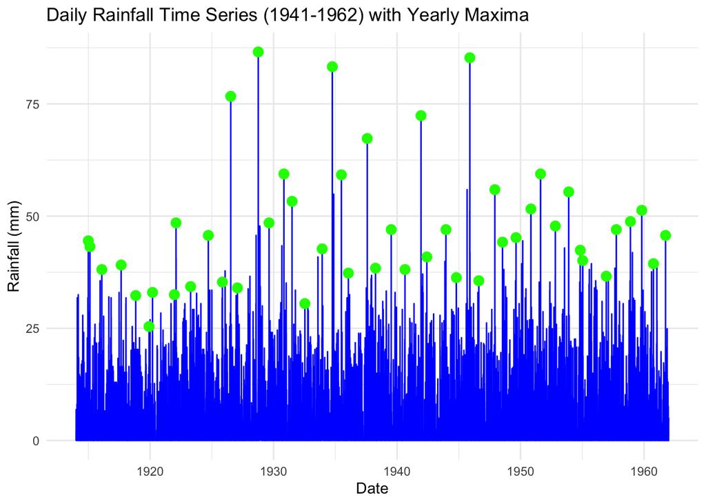

```r
# Extract yearly maxima and their dates
rain_data_y <- rain_data %>%
  mutate(year = year(date)) %>%
  group_by(year) %>%
  filter(rainfall == max(rainfall, na.rm = TRUE)) %>%
  ungroup()

# Plot the time series with yearly maxima
ggplot(rain_data, aes(x = date, y = rainfall)) +
  geom_line(color = 'blue') +
  geom_point(data = rain_data_y, aes(x = date, y = rainfall),
             color = "green", size = 3) +
  labs(title = "Daily Rainfall Time Series (1941-1962) with Yearly Maxima", x = "Date", y = "Rainfall (mm)") +
  theme_minimal()
```

### Distribution of Daily Rainfall

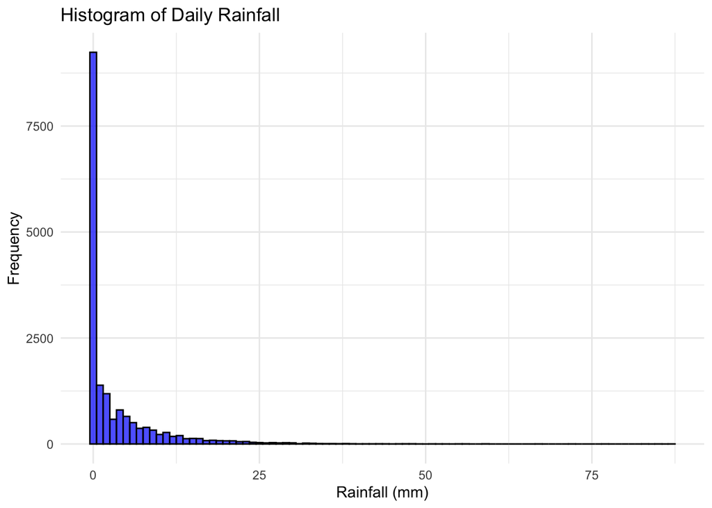

```r
# Histogram of daily rainfall
ggplot(rain_data, aes(x = rainfall)) +
  geom_histogram(binwidth = 1, fill = 'blue', color = 'black', alpha = 0.7) +
  labs(title = "Histogram of Daily Rainfall", x = "Rainfall (mm)", y = "Frequency") +
  theme_minimal()
```

### Yearly Trends

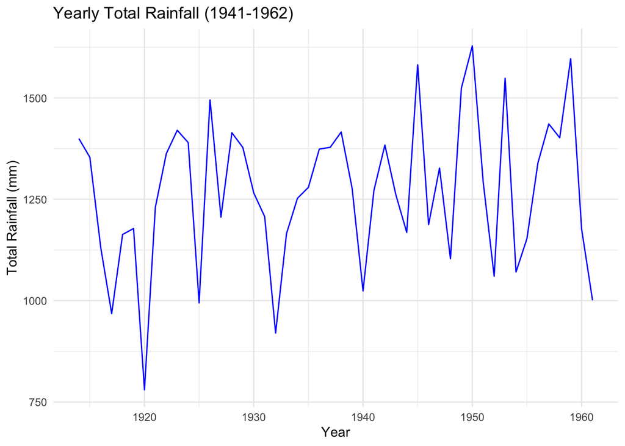

```r
# Plot yearly total rainfall
rain_data %>%
  mutate(year = year(date)) %>%
  group_by(year) %>%
  summarize(total_rainfall = sum(rainfall, na.rm = TRUE)) %>%
  ggplot(aes(x = year, y = total_rainfall)) +
  geom_line(color = 'blue') +
  labs(title = "Yearly Total Rainfall (1941-1962)", x = "Year", y = "Total Rainfall (mm)") +
  theme_minimal()
```

### Histogram of Yearly Maxima

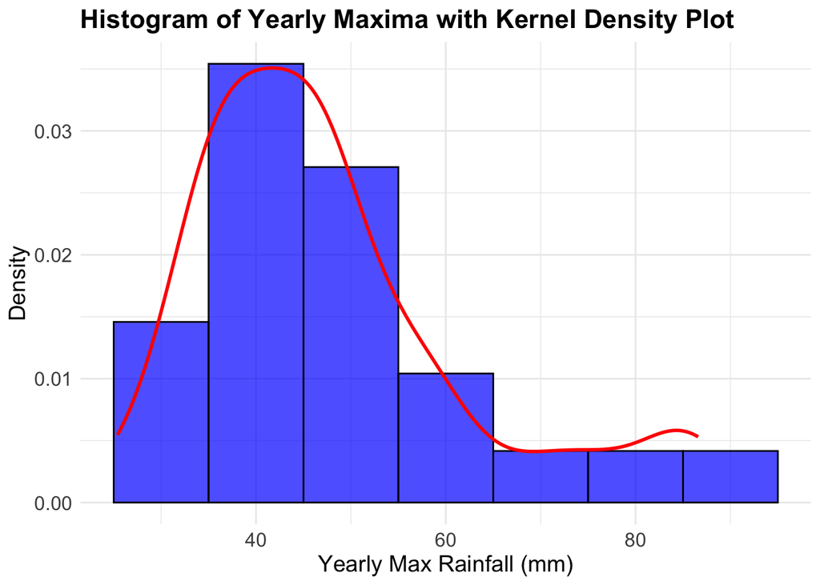

```r
# Histogram of yearly maxima with kernel density plot
ggplot(rain_data_y, aes(x = rainfall)) +
  geom_histogram(aes(y = ..density..), binwidth = 10, fill = 'blue', color = 'black', alpha = 0.7) +
  geom_density(color = 'red', size = 1) +
  labs(title = "Histogram of Yearly Maxima with Kernel Density Plot", x = "Yearly Max Rainfall (mm)", y = "Density") +
  theme_minimal() +
  theme(plot.title = element_text(size = 16, face = "bold"),
        axis.title = element_text(size = 14),
        axis.text = element_text(size = 12))
```

## Yearly Maxima

### Fit GEV Model

```r
# Fit GEV model to yearly maxima
yearly_maxima <- rain_data_y$rainfall
gev_yearly <- extRemes::fevd(yearly_maxima, type = "GEV", method = "MLE")
summary(gev_yearly)
```

```
##
## extRemes::fevd(x = yearly_maxima, type = "GEV", method = "MLE")
##
## [1] "Estimation Method used: MLE"
##
##
##  Negative Log-Likelihood Value:  188.0154
##
##
##  Estimated parameters:
##   location      scale      shape
## 40.7830335  9.7284060  0.1072355
##
##  Standard Error Estimates:
##  location     scale     shape
## 1.5759687 1.1884175 0.1085659
##
##  Estimated parameter covariance matrix.
##            location       scale       shape
## location  2.4836774  0.89366862 -0.05358220
## scale     0.8936686  1.41233609 -0.01690982
## shape    -0.0535822 -0.01690982  0.01178655
##
##  AIC = 382.0309
##
##  BIC = 387.6445
```

### Diagnostics

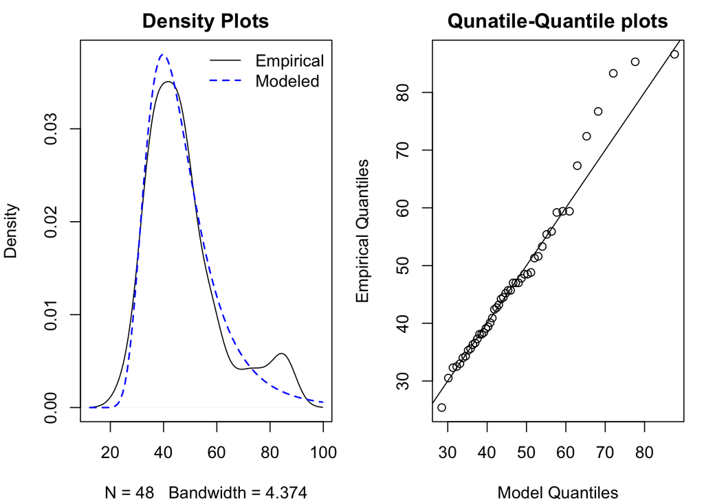

```r
# Diagnostic plots for GEV model of yearly maxima
par(mfrow = c(1, 2), mar = c(4, 4, 2, 1))
plot(gev_yearly, "density", main=c("Density Plots"))
plot(gev_yearly, "qq", main=c("Qunatile-Quantile plots"))
```

**Interpretation**:

- **Quantile Plot**: Also shows a good fit.
- **Density Plot**: Matches well with the empirical data, indicating a good fit.

### Return Level Plot

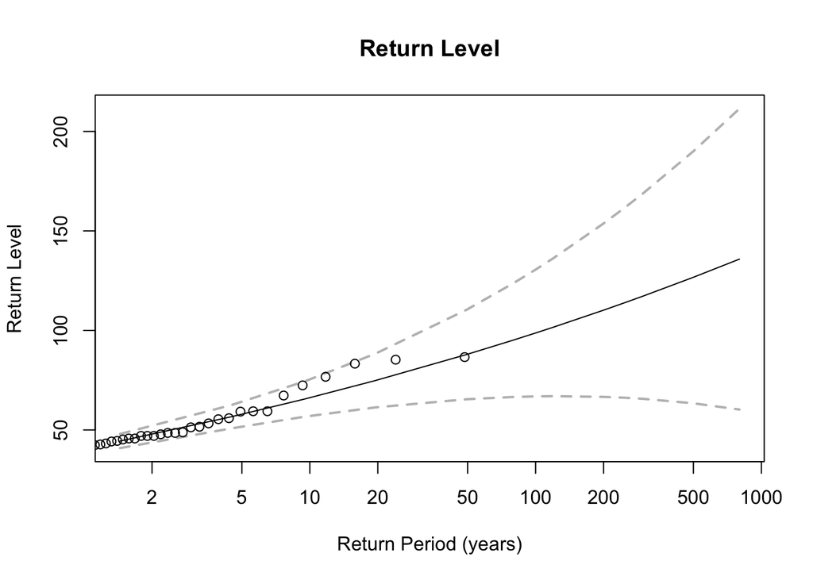

```r
# Return level plot for GEV model of yearly maxima
plot(gev_yearly, type = "rl", main="Return Level")
```

**Interpretation**:

The return level plot for the yearly maxima GEV model shows the expected maximum rainfall for different return periods.

## Generalized Pareto Distribution (GPD) for Exceedances

### Threshold Selection

```r
threshold <- quantile(rain_data$rainfall, probs = 0.70)
sum(rain_data$rainfall > threshold)
```

```
## [1] 5138
```

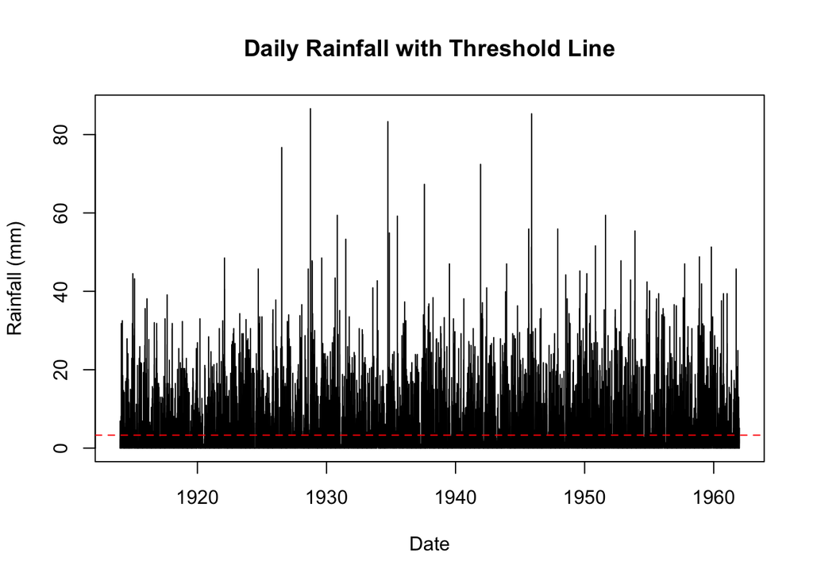

```r
# Plot daily rainfall to visually inspect threshold
plot(rain_data$date, rain_data$rainfall, type = "l", main = "Daily Rainfall with Threshold Line",
     xlab = "Date", ylab = "Rainfall (mm)")
abline(h = threshold, col = "red", lty = 2)  # Example threshold line
```

### Fit GPD Model

```r
# Fit GPD model to exceedances over a chosen threshold
exceedances <- rain_data$rainfall[rain_data$rainfall > threshold] - threshold
gpd_fit <- extRemes::fevd(exceedances, threshold = 0, type = "GP", method = "MLE")
summary(gpd_fit)
```

```
##
## extRemes::fevd(x = exceedances, threshold = 0, type = "GP", method = "MLE")
##
## [1] "Estimation Method used: MLE"
##
##
##  Negative Log-Likelihood Value:  15361.97
##
##
##  Estimated parameters:
##      scale      shape
## 6.83405736 0.06795593
##
##  Standard Error Estimates:
##      scale      shape
## 0.14008342 0.01504745
##
##  Estimated parameter covariance matrix.
##              scale         shape
## scale  0.019623363 -0.0014508985
## shape -0.001450898  0.0002264259
##
##  AIC = 30727.95
##
##  BIC = 30741.04
```

### Diagnostics

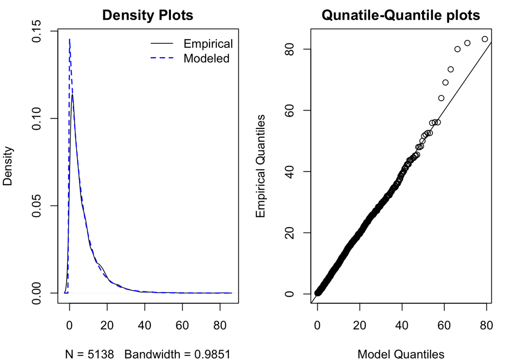

```r
# Diagnostic plots for GPD model
par(mfrow = c(1, 2), mar = c(4, 4, 2, 1))
plot(gpd_fit, "density", main=c("Density Plots"))
plot(gpd_fit, "qq", main=c("Qunatile-Quantile plots"))
```

**Interpretation**:

- **Quantile Plot**: Displays the quantiles for the exceedances, supporting the model fit.
- **Density Plot**: Matches well with the empirical data, indicating a good fit.

### Return Level Plot

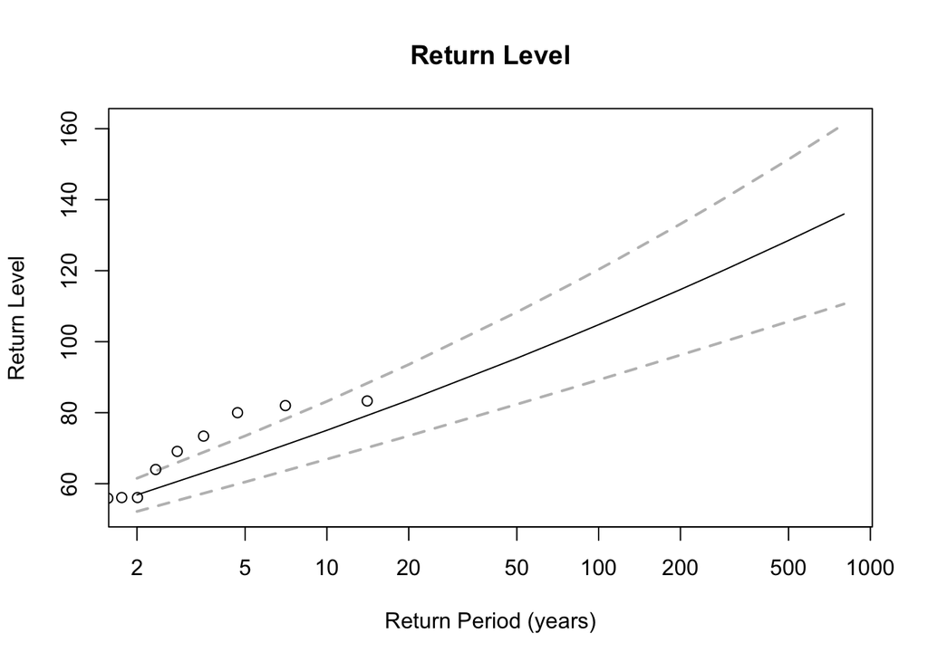

```r
# Return level plot for GPD model
plot(gpd_fit, type = "rl", main="Return Level")
```

**Interpretation**:

The return level plot for the GPD model shows the expected exceedance levels for different return periods, providing insights into the magnitude and frequency of extreme rainfall events.

## Conclusion

This analysis demonstrates the application of extreme value theory to model extreme rainfall events using GEV and GPD distributions. The diagnostic plots and return level plots provide valuable insights into the fit and future predictions of the models.

**Future Work**:  
- **Trend Analysis**: Investigate potential trends in the extreme values over time.  
- **Spatial Analysis**: Extend the analysis to include spatial aspects of rainfall data.  
- **Climate Models**: Integrate climate model outputs to predict future extreme events under different climate scenarios.

# Exercise

Simulate $n = 100 \times 365$ data points from the Cauchy, Gaussian, Exponential, and Pareto distributions. Report the estimated shape parameters and their confidence intervals $\xi$ for both the Generalized Pareto Distribution (GPD) and the Generalized Extreme Value (GEV) models. Fit the GEV model to yearly maxima, where each year has 365 days. Additionally, fit the GPD model for exceedances above a threshold set at the 90th percentile.

The way to simulate the data from this is below

```r
library(VGAM)
num_years <- 100
data_per_year <- 365
# Simulate data for each distribution
cauchy_data <- matrix(rcauchy(num_years * data_per_year), nrow = num_years)
gaussian_data <- matrix(rnorm(num_years * data_per_year), nrow = num_years)
exponential_data <- matrix(rexp(num_years * data_per_year), nrow = num_years)
pareto_data <- matrix(rpareto(num_years * data_per_year, shape = 2), nrow = num_years)  # using VGAM package
```

- Report what did you notice?
- Is this what you expect?